# Risk Factor Analysis

## Outcome Variable

**Outcome Variable:** y_rate_len

## Predictor Variables

**Intervention Variable:** fhtcm

**Adjustment Set:**

unadjusted

## Stratifying Variables

The analysis was stratified on these variable(s):

- agecat
- studyid
- country

## Data Summary

| agecat | studyid | country | fhtcm | n_cell | n |
| --- | --- | --- | --- | --- | --- |
| 0-3 months | ki1000304b-SAS-CompFeed | INDIA | >=167 cm | 94 | 212 |
| 0-3 months | ki1000304b-SAS-CompFeed | INDIA | <162 cm | 53 | 212 |
| 0-3 months | ki1000304b-SAS-CompFeed | INDIA | [162-167) cm | 65 | 212 |
| 0-3 months | ki1101329-Keneba | GAMBIA | >=167 cm | 631 | 965 |
| 0-3 months | ki1101329-Keneba | GAMBIA | <162 cm | 75 | 965 |
| 0-3 months | ki1101329-Keneba | GAMBIA | [162-167) cm | 259 | 965 |
| 0-3 months | ki1119695-PROBIT | BELARUS | >=167 cm | 5492 | 5879 |
| 0-3 months | ki1119695-PROBIT | BELARUS | <162 cm | 76 | 5879 |
| 0-3 months | ki1119695-PROBIT | BELARUS | [162-167) cm | 311 | 5879 |
| 0-3 months | ki1135781-COHORTS | GUATEMALA | >=167 cm | 12 | 81 |
| 0-3 months | ki1135781-COHORTS | GUATEMALA | <162 cm | 39 | 81 |
| 0-3 months | ki1135781-COHORTS | GUATEMALA | [162-167) cm | 30 | 81 |
| 3-6 months | ki1000304b-SAS-CompFeed | INDIA | >=167 cm | 83 | 187 |
| 3-6 months | ki1000304b-SAS-CompFeed | INDIA | <162 cm | 48 | 187 |
| 3-6 months | ki1000304b-SAS-CompFeed | INDIA | [162-167) cm | 56 | 187 |
| 3-6 months | ki1101329-Keneba | GAMBIA | >=167 cm | 673 | 1037 |
| 3-6 months | ki1101329-Keneba | GAMBIA | <162 cm | 74 | 1037 |
| 3-6 months | ki1101329-Keneba | GAMBIA | [162-167) cm | 290 | 1037 |
| 3-6 months | ki1119695-PROBIT | BELARUS | >=167 cm | 4945 | 5292 |
| 3-6 months | ki1119695-PROBIT | BELARUS | <162 cm | 69 | 5292 |
| 3-6 months | ki1119695-PROBIT | BELARUS | [162-167) cm | 278 | 5292 |
| 3-6 months | ki1135781-COHORTS | GUATEMALA | >=167 cm | 18 | 117 |
| 3-6 months | ki1135781-COHORTS | GUATEMALA | <162 cm | 61 | 117 |
| 3-6 months | ki1135781-COHORTS | GUATEMALA | [162-167) cm | 38 | 117 |
| 6-9 months | ki1000304b-SAS-CompFeed | INDIA | >=167 cm | 81 | 180 |
| 6-9 months | ki1000304b-SAS-CompFeed | INDIA | <162 cm | 43 | 180 |
| 6-9 months | ki1000304b-SAS-CompFeed | INDIA | [162-167) cm | 56 | 180 |
| 6-9 months | ki1000304b-SAS-FoodSuppl | INDIA | >=167 cm | 15 | 73 |
| 6-9 months | ki1000304b-SAS-FoodSuppl | INDIA | <162 cm | 27 | 73 |
| 6-9 months | ki1000304b-SAS-FoodSuppl | INDIA | [162-167) cm | 31 | 73 |

[output cut: 72 more lines]

The following strata were considered:

- agecat: 0-3 months, studyid: ki1000304b-SAS-CompFeed, country: INDIA
- agecat: 0-3 months, studyid: ki1101329-Keneba, country: GAMBIA
- agecat: 0-3 months, studyid: ki1119695-PROBIT, country: BELARUS
- agecat: 0-3 months, studyid: ki1135781-COHORTS, country: GUATEMALA
- agecat: 12-15 months, studyid: ki1000304b-SAS-CompFeed, country: INDIA
- agecat: 12-15 months, studyid: ki1000304b-SAS-FoodSuppl, country: INDIA
- agecat: 12-15 months, studyid: ki1101329-Keneba, country: GAMBIA
- agecat: 12-15 months, studyid: ki1119695-PROBIT, country: BELARUS
- agecat: 12-15 months, studyid: ki1135781-COHORTS, country: GUATEMALA
- agecat: 15-18 months, studyid: ki1000304b-SAS-CompFeed, country: INDIA
- agecat: 15-18 months, studyid: ki1000304b-SAS-FoodSuppl, country: INDIA
- agecat: 15-18 months, studyid: ki1101329-Keneba, country: GAMBIA
- agecat: 15-18 months, studyid: ki1119695-PROBIT, country: BELARUS
- agecat: 15-18 months, studyid: ki1135781-COHORTS, country: GUATEMALA
- agecat: 18-21 months, studyid: ki1101329-Keneba, country: GAMBIA
- agecat: 18-21 months, studyid: ki1119695-PROBIT, country: BELARUS
- agecat: 18-21 months, studyid: ki1135781-COHORTS, country: GUATEMALA
- agecat: 21-24 months, studyid: ki1101329-Keneba, country: GAMBIA
- agecat: 21-24 months, studyid: ki1119695-PROBIT, country: BELARUS
- agecat: 21-24 months, studyid: ki1135781-COHORTS, country: GUATEMALA
- agecat: 3-6 months, studyid: ki1000304b-SAS-CompFeed, country: INDIA
- agecat: 3-6 months, studyid: ki1101329-Keneba, country: GAMBIA
- agecat: 3-6 months, studyid: ki1119695-PROBIT, country: BELARUS
- agecat: 3-6 months, studyid: ki1135781-COHORTS, country: GUATEMALA
- agecat: 6-9 months, studyid: ki1000304b-SAS-CompFeed, country: INDIA
- agecat: 6-9 months, studyid: ki1000304b-SAS-FoodSuppl, country: INDIA
- agecat: 6-9 months, studyid: ki1101329-Keneba, country: GAMBIA
- agecat: 6-9 months, studyid: ki1119695-PROBIT, country: BELARUS
- agecat: 6-9 months, studyid: ki1135781-COHORTS, country: GUATEMALA
- agecat: 9-12 months, studyid: ki1000304b-SAS-CompFeed, country: INDIA
- agecat: 9-12 months, studyid: ki1000304b-SAS-FoodSuppl, country: INDIA
- agecat: 9-12 months, studyid: ki1101329-Keneba, country: GAMBIA
- agecat: 9-12 months, studyid: ki1119695-PROBIT, country: BELARUS
- agecat: 9-12 months, studyid: ki1135781-COHORTS, country: GUATEMALA

### Dropped Strata

Some strata were dropped due to rare outcomes:

- agecat: 12-15 months, studyid: ki1119695-PROBIT, country: BELARUS
- agecat: 15-18 months, studyid: ki1119695-PROBIT, country: BELARUS
- agecat: 18-21 months, studyid: ki1119695-PROBIT, country: BELARUS
- agecat: 21-24 months, studyid: ki1119695-PROBIT, country: BELARUS

## Methods Detail

We’re interested in the causal parameters $E[Y_a]$ for all values of $a \in \mathcal{A}$. These parameters represent the mean outcome if, possibly contrary to fact, we intervened to set all units to have $A=a$. Under the randomization and positivity assumptions, these are identified by the statistical parameters $\psi_a=E_W[E_{Y|A,W}(Y|A=a,W)]$. In addition, we’re interested in the mean of $Y$, $E[Y]$ under no intervention (the observed mean). We will estimate these parameters by using SuperLearner to fit the relevant likelihood factors – $E_{Y|A,W}(Y|A=a,W)$ and $p(A=a|W)$, and then updating our likelihood fit using a joint TMLE.

For unadjusted analyses ($W=\{\}$), initial likelihoods were estimated using Lrnr_glm to estimate the simple $E(Y|A)$ and Lrnr_mean to estimate $p(A)$. For adjusted analyses, a small library containing Lrnr_glmnet, Lrnr_xgboost, and Lrnr_mean was used.

Having estimated these parameters, we will then use the delta method to estimate relative risks and attributable risks relative to a prespecified baseline level of $A$.

# Results Detail

## Results Plots

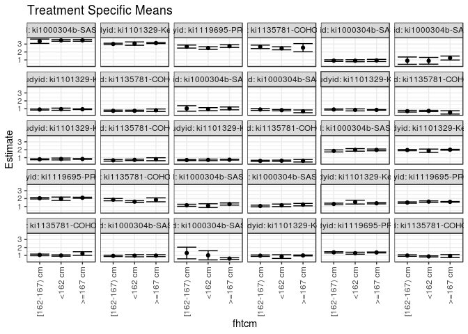

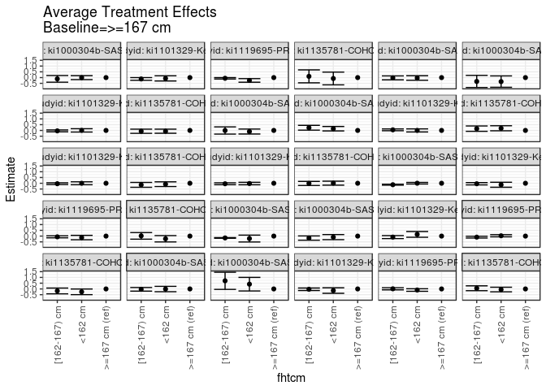

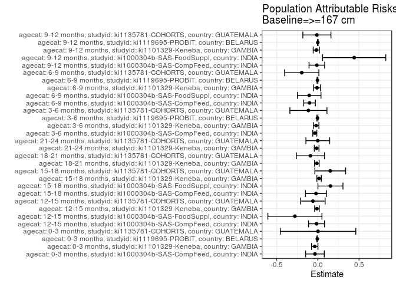

## Results Table

### Parameter: TSM

| agecat | studyid | country | intervention_level | baseline_level | estimate | ci_lower | ci_upper |
| --- | --- | --- | --- | --- | --- | --- | --- |
| 0-3 months | ki1000304b-SAS-CompFeed | INDIA | >=167 cm | NA | 3.4678208 | 3.3567480 | 3.5788936 |
| 0-3 months | ki1000304b-SAS-CompFeed | INDIA | <162 cm | NA | 3.4642186 | 3.3544467 | 3.5739904 |
| 0-3 months | ki1000304b-SAS-CompFeed | INDIA | [162-167) cm | NA | 3.3562763 | 3.0820249 | 3.6305276 |
| 0-3 months | ki1101329-Keneba | GAMBIA | >=167 cm | NA | 3.1319025 | 3.0628593 | 3.2009457 |
| 0-3 months | ki1101329-Keneba | GAMBIA | <162 cm | NA | 3.0615278 | 2.8487174 | 3.2743382 |
| 0-3 months | ki1101329-Keneba | GAMBIA | [162-167) cm | NA | 3.0126540 | 2.9174204 | 3.1078875 |
| 0-3 months | ki1119695-PROBIT | BELARUS | >=167 cm | NA | 2.7442926 | 2.5779446 | 2.9106406 |
| 0-3 months | ki1119695-PROBIT | BELARUS | <162 cm | NA | 2.4980927 | 2.3316706 | 2.6645148 |
| 0-3 months | ki1119695-PROBIT | BELARUS | [162-167) cm | NA | 2.6843350 | 2.4917589 | 2.8769110 |
| 0-3 months | ki1135781-COHORTS | GUATEMALA | >=167 cm | NA | 2.5430812 | 2.0247574 | 3.0614051 |
| 0-3 months | ki1135781-COHORTS | GUATEMALA | <162 cm | NA | 2.4657325 | 2.2769915 | 2.6544735 |
| 0-3 months | ki1135781-COHORTS | GUATEMALA | [162-167) cm | NA | 2.6505981 | 2.4329150 | 2.8682812 |
| 3-6 months | ki1000304b-SAS-CompFeed | INDIA | >=167 cm | NA | 1.9753386 | 1.8652722 | 2.0854049 |
| 3-6 months | ki1000304b-SAS-CompFeed | INDIA | <162 cm | NA | 1.9787676 | 1.8163258 | 2.1412094 |
| 3-6 months | ki1000304b-SAS-CompFeed | INDIA | [162-167) cm | NA | 1.8496967 | 1.7210284 | 1.9783650 |
| 3-6 months | ki1101329-Keneba | GAMBIA | >=167 cm | NA | 2.0003581 | 1.9461897 | 2.0545264 |
| 3-6 months | ki1101329-Keneba | GAMBIA | <162 cm | NA | 1.8704267 | 1.6601132 | 2.0807401 |
| 3-6 months | ki1101329-Keneba | GAMBIA | [162-167) cm | NA | 1.9588819 | 1.8760217 | 2.0417421 |
| 3-6 months | ki1119695-PROBIT | BELARUS | >=167 cm | NA | 2.1046383 | 2.0393700 | 2.1699066 |
| 3-6 months | ki1119695-PROBIT | BELARUS | <162 cm | NA | 1.9776112 | 1.7639349 | 2.1912874 |
| 3-6 months | ki1119695-PROBIT | BELARUS | [162-167) cm | NA | 2.0414963 | 1.9491798 | 2.1338128 |
| 3-6 months | ki1135781-COHORTS | GUATEMALA | >=167 cm | NA | 1.8459410 | 1.5976954 | 2.0941867 |
| 3-6 months | ki1135781-COHORTS | GUATEMALA | <162 cm | NA | 1.6140580 | 1.4957232 | 1.7323927 |
| 3-6 months | ki1135781-COHORTS | GUATEMALA | [162-167) cm | NA | 1.8662420 | 1.7220854 | 2.0103987 |
| 6-9 months | ki1000304b-SAS-CompFeed | INDIA | >=167 cm | NA | 1.3147658 | 1.1806797 | 1.4488518 |
| 6-9 months | ki1000304b-SAS-CompFeed | INDIA | <162 cm | NA | 1.1017831 | 0.8586230 | 1.3449432 |
| 6-9 months | ki1000304b-SAS-CompFeed | INDIA | [162-167) cm | NA | 1.1553985 | 1.0213661 | 1.2894309 |
| 6-9 months | ki1000304b-SAS-FoodSuppl | INDIA | >=167 cm | NA | 1.2358043 | 1.0833093 | 1.3882992 |
| 6-9 months | ki1000304b-SAS-FoodSuppl | INDIA | <162 cm | NA | 1.1479091 | 0.9866915 | 1.3091266 |
| 6-9 months | ki1000304b-SAS-FoodSuppl | INDIA | [162-167) cm | NA | 1.0655954 | 0.9598771 | 1.1713137 |

[output cut: 60 more lines]

### Parameter: E(Y)

| agecat | studyid | country | intervention_level | baseline_level | estimate | ci_lower | ci_upper |
| --- | --- | --- | --- | --- | --- | --- | --- |
| 0-3 months | ki1000304b-SAS-CompFeed | INDIA | NA | NA | 3.4327203 | 3.3283835 | 3.5370571 |
| 0-3 months | ki1101329-Keneba | GAMBIA | NA | NA | 3.0944274 | 3.0398727 | 3.1489822 |
| 0-3 months | ki1119695-PROBIT | BELARUS | NA | NA | 2.7379381 | 2.5700480 | 2.9058282 |
| 0-3 months | ki1135781-COHORTS | GUATEMALA | NA | NA | 2.5456603 | 2.4007516 | 2.6905691 |
| 3-6 months | ki1000304b-SAS-CompFeed | INDIA | NA | NA | 1.9385934 | 1.8051379 | 2.0720489 |
| 3-6 months | ki1101329-Keneba | GAMBIA | NA | NA | 1.9794873 | 1.9347361 | 2.0242384 |
| 3-6 months | ki1119695-PROBIT | BELARUS | NA | NA | 2.0996651 | 2.0336995 | 2.1656306 |
| 3-6 months | ki1135781-COHORTS | GUATEMALA | NA | NA | 1.7316382 | 1.6424348 | 1.8208416 |
| 6-9 months | ki1000304b-SAS-CompFeed | INDIA | NA | NA | 1.2143056 | 1.1169612 | 1.3116501 |
| 6-9 months | ki1000304b-SAS-FoodSuppl | INDIA | NA | NA | 1.1310146 | 1.0486990 | 1.2133302 |
| 6-9 months | ki1101329-Keneba | GAMBIA | NA | NA | 1.3966930 | 1.3370412 | 1.4563449 |
| 6-9 months | ki1119695-PROBIT | BELARUS | NA | NA | 1.5857843 | 1.5415886 | 1.6299801 |
| 6-9 months | ki1135781-COHORTS | GUATEMALA | NA | NA | 1.0374113 | 0.9721703 | 1.1026523 |
| 9-12 months | ki1000304b-SAS-CompFeed | INDIA | NA | NA | 0.9567643 | 0.9076860 | 1.0058427 |
| 9-12 months | ki1000304b-SAS-FoodSuppl | INDIA | NA | NA | 1.0364616 | 0.6613231 | 1.4116001 |
| 9-12 months | ki1101329-Keneba | GAMBIA | NA | NA | 0.9708891 | 0.9222915 | 1.0194866 |
| 9-12 months | ki1119695-PROBIT | BELARUS | NA | NA | 1.3671844 | 1.3123647 | 1.4220041 |
| 9-12 months | ki1135781-COHORTS | GUATEMALA | NA | NA | 0.9069849 | 0.8516062 | 0.9623635 |
| 12-15 months | ki1000304b-SAS-CompFeed | INDIA | NA | NA | 0.9165924 | 0.8288732 | 1.0043116 |
| 12-15 months | ki1000304b-SAS-FoodSuppl | INDIA | NA | NA | 0.9591841 | 0.6972026 | 1.2211656 |
| 12-15 months | ki1101329-Keneba | GAMBIA | NA | NA | 0.9309324 | 0.8952046 | 0.9666602 |
| 12-15 months | ki1135781-COHORTS | GUATEMALA | NA | NA | 0.7532384 | 0.6982068 | 0.8082700 |
| 15-18 months | ki1000304b-SAS-CompFeed | INDIA | NA | NA | 1.0247845 | 0.8342343 | 1.2153347 |
| 15-18 months | ki1000304b-SAS-FoodSuppl | INDIA | NA | NA | 0.8273232 | 0.7583739 | 0.8962726 |
| 15-18 months | ki1101329-Keneba | GAMBIA | NA | NA | 0.8726682 | 0.8384641 | 0.9068722 |
| 15-18 months | ki1135781-COHORTS | GUATEMALA | NA | NA | 0.6902145 | 0.6295356 | 0.7508934 |
| 18-21 months | ki1101329-Keneba | GAMBIA | NA | NA | 0.8178809 | 0.7819425 | 0.8538193 |
| 18-21 months | ki1135781-COHORTS | GUATEMALA | NA | NA | 0.7095919 | 0.6479040 | 0.7712798 |
| 21-24 months | ki1101329-Keneba | GAMBIA | NA | NA | 0.7242397 | 0.6859939 | 0.7624856 |
| 21-24 months | ki1135781-COHORTS | GUATEMALA | NA | NA | 0.6054390 | 0.5549952 | 0.6558829 |

### Parameter: ATE

| agecat | studyid | country | intervention_level | baseline_level | estimate | ci_lower | ci_upper |
| --- | --- | --- | --- | --- | --- | --- | --- |
| 0-3 months | ki1000304b-SAS-CompFeed | INDIA | >=167 cm | >=167 cm | 0.0000000 | 0.0000000 | 0.0000000 |
| 0-3 months | ki1000304b-SAS-CompFeed | INDIA | <162 cm | >=167 cm | -0.0036022 | -0.1729948 | 0.1657904 |
| 0-3 months | ki1000304b-SAS-CompFeed | INDIA | [162-167) cm | >=167 cm | -0.1115445 | -0.4004175 | 0.1773284 |
| 0-3 months | ki1101329-Keneba | GAMBIA | >=167 cm | >=167 cm | 0.0000000 | 0.0000000 | 0.0000000 |
| 0-3 months | ki1101329-Keneba | GAMBIA | <162 cm | >=167 cm | -0.0703748 | -0.2941050 | 0.1533555 |
| 0-3 months | ki1101329-Keneba | GAMBIA | [162-167) cm | >=167 cm | -0.1192486 | -0.2368768 | -0.0016204 |
| 0-3 months | ki1119695-PROBIT | BELARUS | >=167 cm | >=167 cm | 0.0000000 | 0.0000000 | 0.0000000 |
| 0-3 months | ki1119695-PROBIT | BELARUS | <162 cm | >=167 cm | -0.2461999 | -0.4016340 | -0.0907659 |
| 0-3 months | ki1119695-PROBIT | BELARUS | [162-167) cm | >=167 cm | -0.0599577 | -0.1197968 | -0.0001185 |
| 0-3 months | ki1135781-COHORTS | GUATEMALA | >=167 cm | >=167 cm | 0.0000000 | 0.0000000 | 0.0000000 |
| 0-3 months | ki1135781-COHORTS | GUATEMALA | <162 cm | >=167 cm | -0.0773488 | -0.6289671 | 0.4742696 |
| 0-3 months | ki1135781-COHORTS | GUATEMALA | [162-167) cm | >=167 cm | 0.1075169 | -0.4546624 | 0.6696962 |
| 3-6 months | ki1000304b-SAS-CompFeed | INDIA | >=167 cm | >=167 cm | 0.0000000 | 0.0000000 | 0.0000000 |
| 3-6 months | ki1000304b-SAS-CompFeed | INDIA | <162 cm | >=167 cm | 0.0034290 | -0.0674897 | 0.0743478 |
| 3-6 months | ki1000304b-SAS-CompFeed | INDIA | [162-167) cm | >=167 cm | -0.1256418 | -0.1669884 | -0.0842952 |
| 3-6 months | ki1101329-Keneba | GAMBIA | >=167 cm | >=167 cm | 0.0000000 | 0.0000000 | 0.0000000 |
| 3-6 months | ki1101329-Keneba | GAMBIA | <162 cm | >=167 cm | -0.1299314 | -0.3471086 | 0.0872459 |
| 3-6 months | ki1101329-Keneba | GAMBIA | [162-167) cm | >=167 cm | -0.0414761 | -0.1404712 | 0.0575189 |
| 3-6 months | ki1119695-PROBIT | BELARUS | >=167 cm | >=167 cm | 0.0000000 | 0.0000000 | 0.0000000 |
| 3-6 months | ki1119695-PROBIT | BELARUS | <162 cm | >=167 cm | -0.1270271 | -0.3190057 | 0.0649514 |
| 3-6 months | ki1119695-PROBIT | BELARUS | [162-167) cm | >=167 cm | -0.0631420 | -0.1501396 | 0.0238557 |
| 3-6 months | ki1135781-COHORTS | GUATEMALA | >=167 cm | >=167 cm | 0.0000000 | 0.0000000 | 0.0000000 |
| 3-6 months | ki1135781-COHORTS | GUATEMALA | <162 cm | >=167 cm | -0.2318831 | -0.5068904 | 0.0431242 |
| 3-6 months | ki1135781-COHORTS | GUATEMALA | [162-167) cm | >=167 cm | 0.0203010 | -0.2667653 | 0.3073673 |
| 6-9 months | ki1000304b-SAS-CompFeed | INDIA | >=167 cm | >=167 cm | 0.0000000 | 0.0000000 | 0.0000000 |
| 6-9 months | ki1000304b-SAS-CompFeed | INDIA | <162 cm | >=167 cm | -0.2129827 | -0.5106105 | 0.0846452 |
| 6-9 months | ki1000304b-SAS-CompFeed | INDIA | [162-167) cm | >=167 cm | -0.1593673 | -0.1859048 | -0.1328297 |
| 6-9 months | ki1000304b-SAS-FoodSuppl | INDIA | >=167 cm | >=167 cm | 0.0000000 | 0.0000000 | 0.0000000 |
| 6-9 months | ki1000304b-SAS-FoodSuppl | INDIA | <162 cm | >=167 cm | -0.0878952 | -0.3098092 | 0.1340188 |
| 6-9 months | ki1000304b-SAS-FoodSuppl | INDIA | [162-167) cm | >=167 cm | -0.1702089 | -0.3557650 | 0.0153473 |

[output cut: 60 more lines]

### Parameter: PAR

| agecat | studyid | country | intervention_level | baseline_level | estimate | ci_lower | ci_upper |
| --- | --- | --- | --- | --- | --- | --- | --- |
| 0-3 months | ki1000304b-SAS-CompFeed | INDIA | >=167 cm | NA | -0.0351005 | -0.1483725 | 0.0781714 |
| 0-3 months | ki1101329-Keneba | GAMBIA | >=167 cm | NA | -0.0374751 | -0.0763220 | 0.0013718 |
| 0-3 months | ki1119695-PROBIT | BELARUS | >=167 cm | NA | -0.0063545 | -0.0119724 | -0.0007365 |
| 0-3 months | ki1135781-COHORTS | GUATEMALA | >=167 cm | NA | 0.0025791 | -0.4557388 | 0.4608970 |
| 3-6 months | ki1000304b-SAS-CompFeed | INDIA | >=167 cm | NA | -0.0367452 | -0.0610318 | -0.0124585 |
| 3-6 months | ki1101329-Keneba | GAMBIA | >=167 cm | NA | -0.0208708 | -0.0544616 | 0.0127200 |
| 3-6 months | ki1119695-PROBIT | BELARUS | >=167 cm | NA | -0.0049732 | -0.0110155 | 0.0010690 |
| 3-6 months | ki1135781-COHORTS | GUATEMALA | >=167 cm | NA | -0.1143028 | -0.3392946 | 0.1106890 |
| 6-9 months | ki1000304b-SAS-CompFeed | INDIA | >=167 cm | NA | -0.1004601 | -0.1714096 | -0.0295107 |
| 6-9 months | ki1000304b-SAS-FoodSuppl | INDIA | >=167 cm | NA | -0.1047897 | -0.2478765 | 0.0382972 |
| 6-9 months | ki1101329-Keneba | GAMBIA | >=167 cm | NA | -0.0098969 | -0.0511406 | 0.0313469 |
| 6-9 months | ki1119695-PROBIT | BELARUS | >=167 cm | NA | -0.0043816 | -0.0093139 | 0.0005506 |
| 6-9 months | ki1135781-COHORTS | GUATEMALA | >=167 cm | NA | -0.1953794 | -0.4032406 | 0.0124818 |
| 9-12 months | ki1000304b-SAS-CompFeed | INDIA | >=167 cm | NA | -0.0120909 | -0.1067168 | 0.0825350 |
| 9-12 months | ki1000304b-SAS-FoodSuppl | INDIA | >=167 cm | NA | 0.4414344 | 0.0579962 | 0.8248727 |
| 9-12 months | ki1101329-Keneba | GAMBIA | >=167 cm | NA | -0.0185846 | -0.0561088 | 0.0189396 |
| 9-12 months | ki1119695-PROBIT | BELARUS | >=167 cm | NA | -0.0005522 | -0.0048493 | 0.0037449 |
| 9-12 months | ki1135781-COHORTS | GUATEMALA | >=167 cm | NA | -0.0114053 | -0.1818602 | 0.1590496 |
| 12-15 months | ki1000304b-SAS-CompFeed | INDIA | >=167 cm | NA | -0.0156474 | -0.1128827 | 0.0815878 |
| 12-15 months | ki1000304b-SAS-FoodSuppl | INDIA | >=167 cm | NA | -0.2782352 | -0.6064990 | 0.0500285 |
| 12-15 months | ki1101329-Keneba | GAMBIA | >=167 cm | NA | -0.0108070 | -0.0385798 | 0.0169658 |
| 12-15 months | ki1135781-COHORTS | GUATEMALA | >=167 cm | NA | -0.0597771 | -0.2082938 | 0.0887395 |
| 15-18 months | ki1000304b-SAS-CompFeed | INDIA | >=167 cm | NA | -0.0222778 | -0.1498580 | 0.1053025 |
| 15-18 months | ki1000304b-SAS-FoodSuppl | INDIA | >=167 cm | NA | 0.1531012 | 0.0012731 | 0.3049294 |
| 15-18 months | ki1101329-Keneba | GAMBIA | >=167 cm | NA | 0.0153091 | -0.0114621 | 0.0420803 |
| 15-18 months | ki1135781-COHORTS | GUATEMALA | >=167 cm | NA | 0.1506404 | -0.0361582 | 0.3374389 |
| 18-21 months | ki1101329-Keneba | GAMBIA | >=167 cm | NA | -0.0118564 | -0.0399481 | 0.0162353 |
| 18-21 months | ki1135781-COHORTS | GUATEMALA | >=167 cm | NA | -0.0897002 | -0.2600184 | 0.0806179 |
| 21-24 months | ki1101329-Keneba | GAMBIA | >=167 cm | NA | -0.0144538 | -0.0429285 | 0.0140208 |
| 21-24 months | ki1135781-COHORTS | GUATEMALA | >=167 cm | NA | -0.0004538 | -0.1448889 | 0.1439812 |